# Ontario Democracy Under Pandemic: Explaining How the Ford Government Prevailed During COVID-19

# Citations

1. Allaire, JJ, et al. Rmarkdown: Dynamic Documents for R. 2020, github.com/rstudio/rmarkdown. Accessed 9 Oct. 2020. R package version 2.4.
2. “As Pandemic Endures, Three-in-Ten Canadians Say Restrictions in Their Own Province Don’t Go Far Enough.” Angus Reid Institute, 13 Aug. 2020, angusreid.org/covid-19-provincial-leadership/. Accessed 10 Oct. 2020.
3. “Canadians’ Personal Financial Circumstances Improving, but Majority Will Defer Major Purchases in the next Year.” Angus Reid Institute, 23 July 2020, angusreid.org/covid-19-finances-spending/. Accessed 10 Oct. 2020.
4. Canseco, Mario. “Satisfaction with COVID-19 Handling Drops in Ontario and Quebec.” Research Co., 19 May 2020, researchco.ca/2020/05/19/canada-governments-covid19/. Accessed 10 Oct. 2020.
5. Government of Canada, Statistics Canada. “2016 Census Data Tables – Age (in Single Years) and Average Age (127) and Sex (3) for the Population of Canada, Provinces and Territories, Census Divisions, Census Subdivisions and Dissemination Areas, 2016 Census - 100% Data.” Statcan.Gc.Ca, 2016, www12.statcan.gc.ca/census-recensement/2016/dp-pd/dt-td/Rp-eng.cfm?TABID=2&LANG=E&APATH=3&DETAIL=0&DIM=0&FL=A&FREE=0&GC=0&GID=0&GK=0&GRP=1&PID=109525&PRID=35&PTYPE=109445&S=0& SHOWALL=0&SUB=0&Temporal=2016&THEME=115&VID=0&VNAMEE=&VNAMEF=&D1=0&D2=0&D3=0&D4=0&D5=0&D6=0. Accessed 10 Oct. 2020.
6. Hadley Wickham. Ggplot2 Elegant Graphics for Data Analysis. Cham Springer International Publishing, 2016. Larmarange, Joseph. Labelled: Manipulating Labelled Data. 2020, larmarange.github.io/labelled/. package version 2.7.0.
7. Kennedy, Courney, and Hannah Hartig. “Response Rates in Telephone Surveys Have Resumed Their Decline.” Pew Research Center, 12 Feb. 2019, www.pewresearch.org/fact-tank/2019/02/27/response-rates-in-telephone-surveys-have-resumed-their-decline/.
8. “Labour Market Report, August 2020.” Ontario.Ca, Ministry of Labour, Training and Skills Development, 28 Sept. 2020, www.ontario.ca/page/labour-market-report-august-2020. Accessed 9 Oct. 2020.
9. Oct 8, Janet E. Silver, and 2020 6:21pm. “As COVID Cases Rise, so Do Calls for More Mental-Health Funding.” IPolitics, 8 Oct. 2020, ipolitics.ca/2020/10/08/as-covid-cases-rise-so-do-calls-for-more-mental-health-funding/. Accessed 10 Oct. 2020.
10. “Ontario Election Results From CBC News.” CBC News, newsinteractives.cbc.ca/onvotes/results/.
11. “Ontario Newsroom | Salle de Presse de l’Ontario.” News.Ontario.Ca, 30 Sept. 2020, news.ontario.ca/en/release/58602/ontario-releases-updated-covid-19-modelling-for-second-wave. Accessed 10 Oct. 2020.
12. “Ontario Spotlight: As COVID-19 Cases Climb, Can the Ford Government Maintain the Political Goodwill It’s Earned?” Angus Reid Institute, 18 Sept. 2020, angusreid.org/ontario-government-august-2020/. Accessed 10 Oct. 2020.
13. Ore, Jonathan. “Mixed Reception to Feds’ COVID-19 Response among Canadians as Pandemic Marches on | CBC Radio.” CBC, 12 July 2020, www.cbc.ca/radio/checkup/what-grade-do-you-give-the-trudeau-government-on-covid-19-1.5643270/mixed-reception-to-feds-covid-19-response-among-canadians-as-pandemic-marches-on-1.5646508. Accessed 10 Oct. 2020.
14. Press, Jordan. “Canadian Economy Posted Steepest Decline on Record as Coronavirus Struck: StatCan.” CTVNews, 28 Aug. 2020, www.ctvnews.ca/business/canadian-economy-posted-steepest-decline-on-record-as-coronavirus-struck-statcan-1.5082814. Accessed 10 Oct. 2020.
15. NW, 1615 L. St, et al. “Our Survey Methodology in Detail.” Pew Research Center Methods, www.pewresearch.org/methods/u-s-survey-research/our-survey-methodology-in-detail/. Accessed 9 Oct. 2020.
16. R Core Team. R: A Language and Environment for Statistical Computing. Vienna, Austria, R Foundation for Statistical Computing, 2020, www.R-project.org/. Accessed 9 Oct. 2020
17. “Second Wave Angst: COVID-19 Concern Levels Rebound to April Highs as Canadians Brace for Worse to Come.” Angus Reid Institute, 30 Sept. 2020, angusreid.org/covid-second-wave-september/. Accessed 10 Oct. 2020.
18. Szperling, Peter. “Anxiety Levels Increasing during COVID-19 Pandemic: Study.” CityTV Ottawa, 24 Sept. 2020, ottawa.ctvnews.ca/anxiety-levels-increasing-during-covid-19-pandemic-study-1.5119162. Accessed 8 Oct. 2020.
19. “So Long, Office Space? Two-Thirds of Canadians Who Work from Home Expect It to Continue after Pandemic.” Angus Reid Institute, 11 June 2020, angusreid.org/coronavirus-work-from-home/. Accessed 10 Oct. 2020.
20. Weber, Bob. “COVID-19 Causing Stress, Depression and Obsessive Behaviour: Survey.” CTV News, 26 Sept. 2020. Accessed 8 Oct. 2020.
21. Wickham, Hadley, et al. Dplyr: A Grammar of Data Manipulation. 2020, dplyr.tidyverse.org, github.com/tidyverse/dplyr. Accessed 9 Oct. 2020.
22. Wickham, Hadley, and Jennifer Bryan. Readxl: Read Excel Files. 2019, readxl.tidyverse.org, github.com/tidyverse/readxl.
23. Wu, Changbao, and Mary E. Thompson. Sampling Theory and Practice. Springer.
24. Yihui Xie, et al. R Markdown Cookbook.. Chapman and Hall/CRC, 2020.
25. Yihui Xie, et al. R Markdown: The Definitive Guide.. Chapman and Hall/CRC, 2018.
26. Canada, Elections. “Description of the National Register of Electors.” Www.Elections.Ca, 7 July 2020, www.elections.ca/content.aspx?section=vot&dir=reg/des&document=index&lang=e. Accessed 9 Oct. 2020.

# Appendix

Link to code: https://github.com/1234567980/STA302-PS2

Link to survey:https://www.surveymonkey.com/r/Preview/?sm=yjJjeiM3KvfrNAOGiO2B2A4A0UKGkHgR82Qt83bwpG1fDl1g_2Fr2TY8dawJ2IdzlF

Survey:

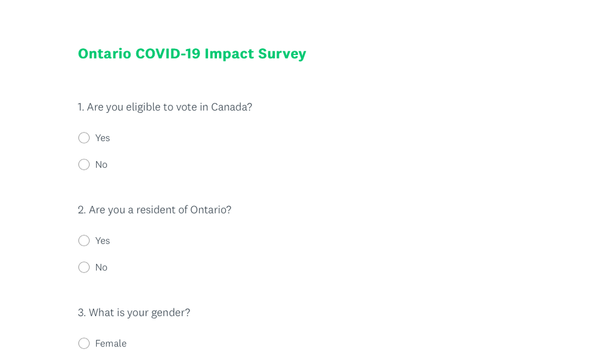

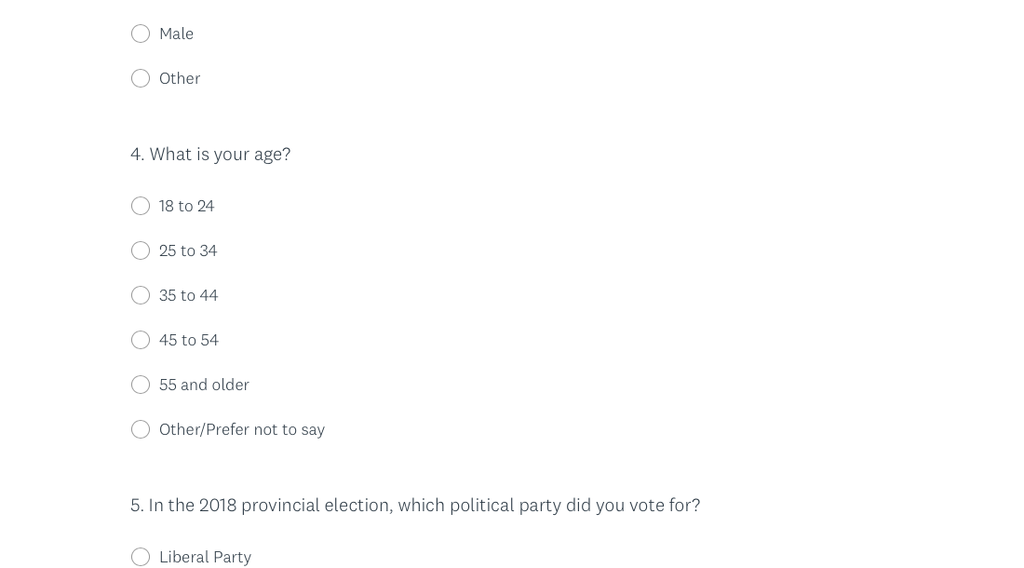

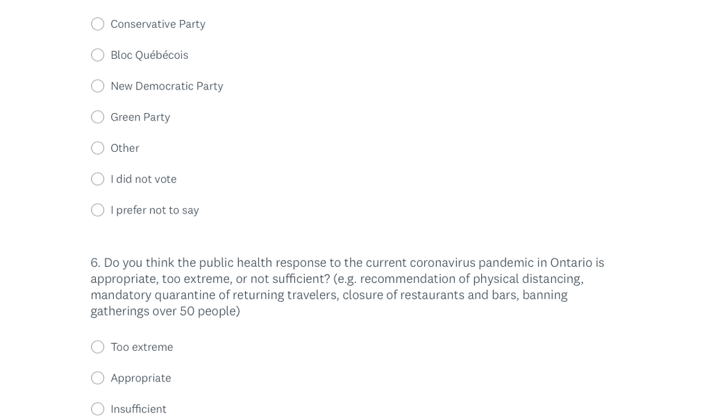

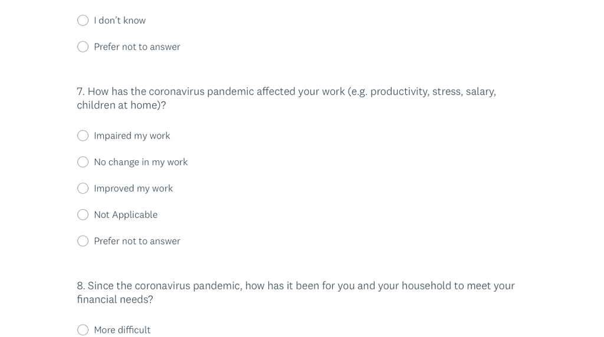

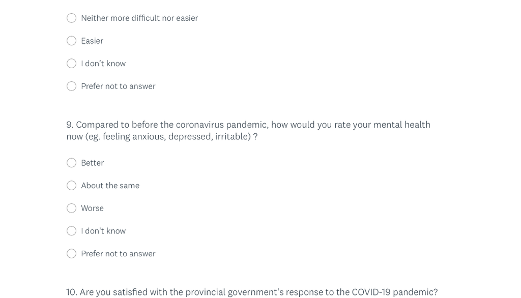

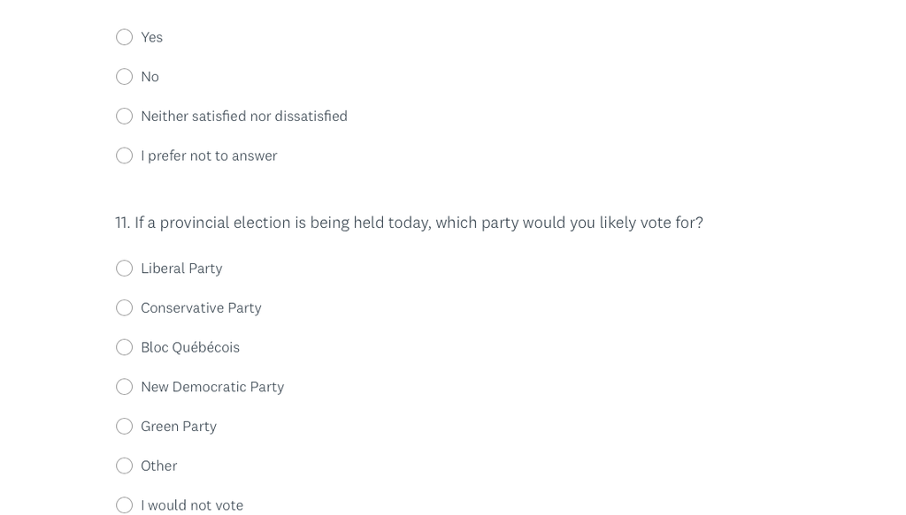

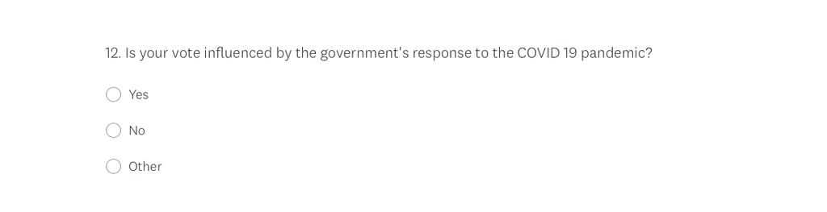